# 《R语言》第4章：字符处理

[返回课程主页](https://psychbruce.github.io/RCourse/)

授课教师：包寒吴霜

版权声明：本套课程材料开源，使用和分享必须遵守「创作共用许可协议 CC BY-NC-SA」（来源引用-非商业用途使用-以相同方式共享）。

[figure not shown]

# Chap04：字符处理

#### 往期要点回顾

- [Chap03 # 数据框（data frame）](https://psychbruce.github.io/RCourse/Chap03#%E6%95%B0%E6%8D%AE%E6%A1%86data-frame)
- [Chap03 # “一站式”数据导入导出](https://psychbruce.github.io/RCourse/Chap03#%E5%A4%96%E9%83%A8%E6%95%B0%E6%8D%AE%E5%AF%BC%E5%85%A5%E5%AF%BC%E5%87%BA)

#### 本章要点目录

- 【探索发现】如何提取电影变量？
- 【探索发现】如何统计《心理学报》历届编委会成员频次？
- 【知识点】正则表达式（重点）
- 【实践1】字符匹配
- 【实践2】条件匹配
- 【实践3】预查匹配
- 【实践4】字符串综合处理（重点）
- 【探索发现】stringr包的函数功能

```r
## 本章所需R包
library(bruceR)
library(stringr)  # 字符串处理（加载bruceR时已默认加载stringr）
library(rvest)  # 网络爬虫
```

# 正则表达式基础

[figure not shown]

https://movie.douban.com/subject/34780991/

```r
info = "
导演: 饺子
编剧: 饺子
主演: 吕艳婷 / 囧森瑟夫 / 瀚墨 / 陈浩 / 绿绮 / 张珈铭 / ...
类型: 剧情 / 喜剧 / 动画 / 奇幻
制片国家/地区: 中国大陆
语言: 汉语普通话
上映日期: 2025-01-29(中国大陆)
片长: 144分钟
又名: 哪吒2 / 哪吒2之魔童闹海 / Ne Zha 2
IMDb: tt34956443
"
info
```

```
[1] "\n导演: 饺子\n编剧: 饺子\n主演: 吕艳婷 / 囧森瑟夫 / 瀚墨 / 陈浩 / 绿绮 / 张珈铭 / ...\n类型: 剧情 / 喜剧 / 动画 / 奇幻\n制片国家/地区: 中国大陆\n语言: 汉语普通话\n上映日期: 2025-01-29(中国大陆)\n片长: 144分钟\n又名: 哪吒2 / 哪吒2之魔童闹海 / Ne Zha 2\nIMDb: tt34956443\n"
```

```r
cat(info)
```

```
导演: 饺子
编剧: 饺子
主演: 吕艳婷 / 囧森瑟夫 / 瀚墨 / 陈浩 / 绿绮 / 张珈铭 / ...
类型: 剧情 / 喜剧 / 动画 / 奇幻
制片国家/地区: 中国大陆
语言: 汉语普通话
上映日期: 2025-01-29(中国大陆)
片长: 144分钟
又名: 哪吒2 / 哪吒2之魔童闹海 / Ne Zha 2
IMDb: tt34956443
```

#### 【探索发现】如何提取电影变量？

- 如何从原始文本数据中提取：
  - 导演：“饺子”
  - 类型：“剧情 / 喜剧 / 动画 / 奇幻”
  - 片长：“144”
  - 上映日期：“2025-01-29”

```r
str_extract(info, "(?<=导演: ).*(?=\\n)")
```

```
[1] "饺子"
```

```r
str_extract(info, "(?<=类型: ).*(?=\\n)")
```

```
[1] "剧情 / 喜剧 / 动画 / 奇幻"
```

```r
str_extract(info, "(?<=类型: ).*(?=\\n)") %>%
  str_split(" / ")
```

```
[[1]]
[1] "剧情" "喜剧" "动画" "奇幻"
```

```r
str_extract(info, "(?<=片长: ).*(?=分钟\\n)")
```

```
[1] "144"
```

```r
str_extract(info, "(?<=上映日期: ).*(?=\\n)")
```

```
[1] "2025-01-29(中国大陆)"
```

```r
str_extract(info, "(?<=上映日期: ).*(?=\\n)") %>%
  str_extract("\\d{4}-\\d{2}-\\d{2}")
```

```
[1] "2025-01-29"
```

```r
str_extract(info, "(?<=上映日期: ).*(?=\\n)") %>%
  str_extract("\\d{4}-\\d{2}-\\d{2}") %>%
  str_remove_all("-")
```

```
[1] "20250129"
```

#### 【探索发现】如何统计《心理学报》历届编委会成员频次？

《心理学报》编委会：https://journal.psych.ac.cn/xlxb/CN/column/column3.shtml

```r
url = "https://journal.psych.ac.cn/xlxb/CN/column/column3.shtml"
xml = read_html(url)
text = xml %>% html_element(".content_nr li") %>% html_text()
text %>% str_split("\\s{3,}") %>% unlist()
```

```
  [1] ""
  [2] "主编："
  [3] "蒋  毅（中国科学院心理研究所）"
  [4] "副主编："
  [5] "甘怡群（北京大学）"
  [6] "胡晓晴（香港大学）"
  [7] "李兴珊（中国科学院心理研究所）"
  [8] "刘  超（北京师范大学）"
  [9] "施俊琦 (浙江大学)"
 [10] "辛自强（中国人民大学）"
 [11] "邱炳武（中国科学院心理研究所）"
 [12] "编委："
 [13] "陈安涛 (上海交通大学)"
 [14] "陈楚侨（香港大学）"
 [15] "陈  红（西南大学）"
```

[output cut: 111 more lines]

```r
text %>%
  str_split("\\s{3,}") %>%
  unlist() %>%
  str_extract("(?<=主编：|副主编：|编委：).*|.*(?=（)") %>%
  str_split("、|主编：|副主编：|编委：") %>%
  unlist() %>%
  na.omit() %>%
  str_remove_all("\\s") %>%
  str_subset("编委会|[a-z]|^$", negate=TRUE) %>%
  Freq(sort="-")
```

```
Frequency Statistics:
─────────────
        N   %
─────────────
陈永明  7 1.6
林崇德  7 1.6
林仲贤  7 1.6
王甦    7 1.6
黄希庭  6 1.4
邱炳武  6 1.4
车文博  5 1.2
陈烜之  5 1.2
朱滢    5 1.2
陈欣银  4 0.9
方富熹  4 0.9
蒋毅    4 0.9
李纾    4 0.9
李心天  4 0.9
李兴珊  4 0.9
凌文辁  4 0.9
沈德立  4 0.9
舒华    4 0.9
苏彦捷  4 0.9
徐联仓  4 0.9
阎书昌  4 0.9
张厚粲  4 0.9
张侃    4 0.9
张雷    4 0.9
张妙清  4 0.9
白学军  3 0.7
蔡华俭  3 0.7
陈红    3 0.7
陈元晖  3 0.7
丁锦红  3 0.7
杜峰    3 0.7
杜忆    3 0.7
傅世敏  3 0.7
甘怡群  3 0.7
管林初  3 0.7
郭春彦  3 0.7
```

[output cut: 128 more lines]

```
吴江霖  1 0.2
许尚侠  1 0.2
许政援  1 0.2
薛贵    1 0.2
严进    1 0.2
杨鑫辉  1 0.2
叶铮    1 0.2
张必隐  1 0.2
张结海  1 0.2
张庆林  1 0.2
张述祖  1 0.2
赵志裕  1 0.2
左梦兰  1 0.2
─────────────
Total N = 432
```

#### 正则表达式在社会科学研究中有什么用？

现在的社会科学研究越来越依赖大数据和文本分析，经常要和海量文本打交道：10万条微博、5万份问卷、几百年的历史档案……正则表达式就是处理文本数据的“神兵利器”。

1. **清洗和整理数据（数据“洗澡”）**

从网上爬下来的数据经常很“脏”：夹杂着广告代码、乱码、多余的空格。正则表达式可以一键把这些垃圾清理掉，留下干净的文字。原本需要手动清理几万条数据，可能需要一个团队干一周；现在用几行正则表达式代码，几秒钟就能完成，而且准确率极高。

2. **提取文本中信息（信息“采矿”）**

比如你想研究“幸福感”这个词在社交媒体上的用法。正则表达式可以帮你找出所有包含“幸福”的句子，并且自动把“幸福”前面是谁在说（比如“我觉得幸福”“他感到幸福”）提取出来，又快又准。

3. **内容分析与编码（将文字变数据）**

社会科学研究经常需要对文本进行分类和编码。比如，你想分析新闻报道对某个社会事件的态度是“正面”、“负面”还是“中立”。可以先设定好规则，比如包含“赞赏”、“支持”、“成功”等词的归为“正面”，包含“反对”、“批评”、“问题”等词的归为“负面”。然后，正则表达式就能自动扫描所有文章，并根据这些关键词的出现情况，给每一篇文章贴上“态度”标签。几秒钟就能把几万条帖子分类完毕，这不仅比人工阅读编码快无数倍，而且标准完全统一，避免了因为研究者疲劳或个人主观判断带来的误差。它让定性研究可以拥有定量分析的规模。

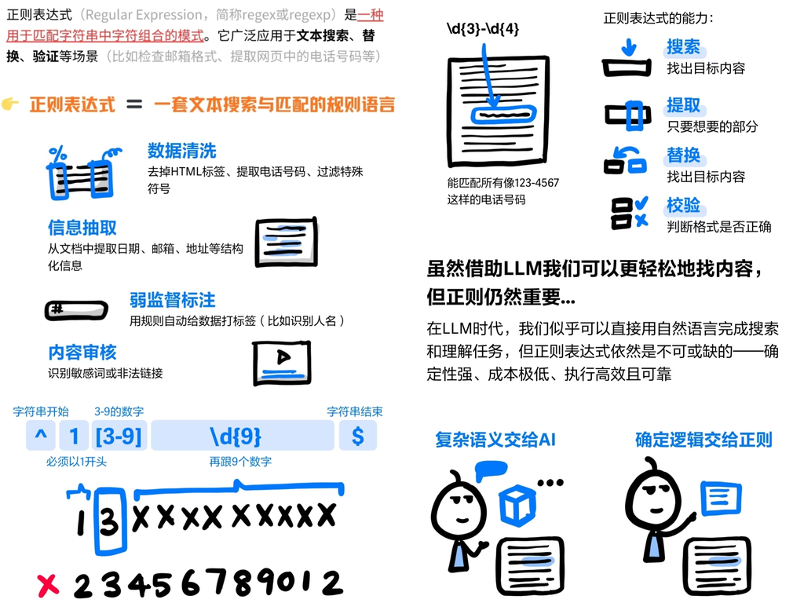

正则表达式图解（图片源自网络）

#### 【知识点】正则表达式

##### 正则表达式 / 规律表达式（regular/pattern expression，RegEx）

简单来说，正则表达式就是一套用来**描述文本规则的“密码”**。它用一些特殊符号（比如`*`、`+`、`?`、`[]`）组合成“指令”，让电脑按照这些规则去文本的海洋里精准地找到你想要的内容（比如一定要是“蓝色”之后紧跟的“汽车”，而不是“红色汽车”）。

- **含义：描述字符串规律（模式）的表达式**
- **用途：根据模式，匹配字符（自动处理文本）**
  - **“大海捞针”（词频统计）**：从海量的文本数据里，快速找到符合特定模式的字词、句子或段落
  - **“点石成金”（数据清洗）**：找到之后，可以对这些内容进行批量的修改、删除、替换或提取，整理成数据分析所需要的格式
  - **“去伪存真”（条件判断）**：还可以用来检查信息格式是否正确，比如手机号码是不是11位、邮箱地址里有没有“@”符号等
- 正则表达式的“密码”其实很有逻辑，也很好理解，比如：
  - `\d`：代表“任何一个数字”（0-9），就像在说“给我找一个数字”
  - `[a-z]`：代表“任何一个英文小写字母”，就像在说“给我找一个小写字母”
  - `*`：代表“前面的东西可以出现零次或多次”，就像在说“这个模式可以重复无数次”
  - `+`：代表“前面的东西至少出现一次”，就像在说“这个模式至少要出现一次”
  - `.`：代表“任何一个字符”（除了换行符），就像一张万能牌，可以代替任何一个字符

> 一旦学会，你就拥有了一种神奇的能力：别人还在一条条复制粘贴、肉眼搜索的时候，你已经可以喝着咖啡，轻松看着电脑帮你把几万条甚至几百万条文本数据在几秒之内自动整理好。这就是正则表达式的魅力——把繁琐的手工劳动，变成自动化的“魔法”。

## （1）字符匹配

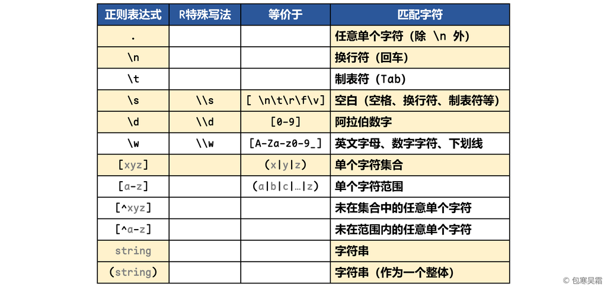

#### 【实践1】字符匹配

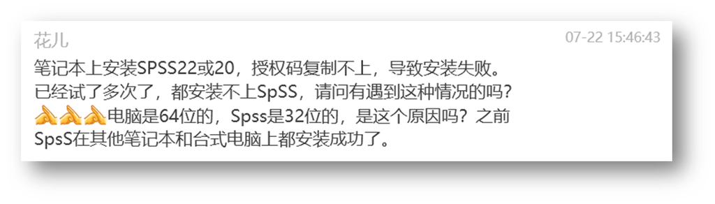

```r
text = "笔记本上安装SPSS22或20，授权码复制不上，导致安装失败。已经试了多次了，都安装不上SpSS，请问有遇到这种情况的吗？电脑是64位的，Spss是32位的，是这个原因吗？之前SpsS在其他笔记本和台式电脑上都安装成功了。"
cat(text)
```

```
笔记本上安装SPSS22或20，授权码复制不上，导致安装失败。已经试了多次了，都安装不上SpSS，请问有遇到这种情况的吗？电脑是64位的，Spss是32位的，是这个原因吗？之前SpsS在其他笔记本和台式电脑上都安装成功了。
```

```r
str_extract_all(text, "SPSS")  # 完整字符串
```

```
[[1]]
[1] "SPSS"
```

```r
str_extract_all(text, "SPSS|Spss")  # "|"表示或者
```

```
[[1]]
[1] "SPSS" "Spss"
```

```r
str_extract_all(text, "[SPSS|spss]")  # 思考：为什么？
```

```
[[1]]
 [1] "S" "P" "S" "S" "S" "p" "S" "S" "S" "p" "s" "s" "S" "p" "s" "S"
```

```r
str_extract_all(text, "[SsPp]")
```

```
[[1]]
 [1] "S" "P" "S" "S" "S" "p" "S" "S" "S" "p" "s" "s" "S" "p" "s" "S"
```

```r
str_extract_all(text, "[Ss][Pp][Ss][Ss]")
```

```
[[1]]
[1] "SPSS" "SpSS" "Spss" "SpsS"
```

```r
str_extract_all(text, "\\d")
```

```
[[1]]
[1] "2" "2" "2" "0" "6" "4" "3" "2"
```

```r
str_extract_all(text, "\\d\\d")
```

```
[[1]]
[1] "22" "20" "64" "32"
```

```r
str_extract_all(text, "\\d\\d位")
```

```
[[1]]
[1] "64位" "32位"
```

## （2）条件匹配

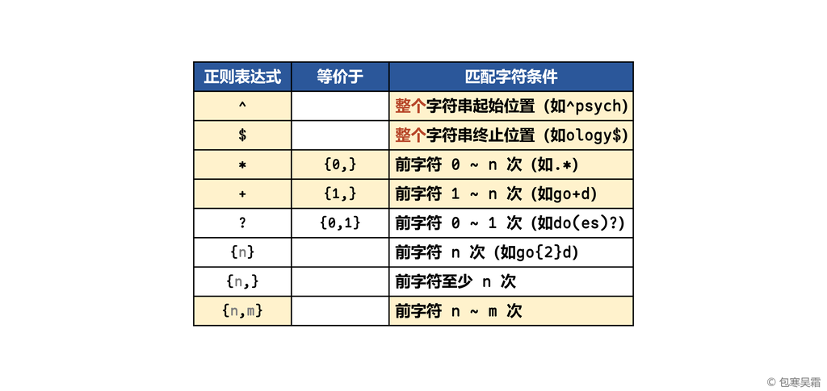

#### 【实践2】条件匹配

```r
text = "笔记本上安装SPSS22或20，授权码复制不上，导致安装失败。已经试了多次了，都安装不上SpSS，请问有遇到这种情况的吗？电脑是64位的，Spss是32位的，是这个原因吗？之前SpsS在其他笔记本和台式电脑上都安装成功了。"
cat(text)
```

```
笔记本上安装SPSS22或20，授权码复制不上，导致安装失败。已经试了多次了，都安装不上SpSS，请问有遇到这种情况的吗？电脑是64位的，Spss是32位的，是这个原因吗？之前SpsS在其他笔记本和台式电脑上都安装成功了。
```

```r
str_extract_all(text, "\\d{2}位")
```

```
[[1]]
[1] "64位" "32位"
```

```r
str_extract_all(text, "[SsPp]{4}")
```

```
[[1]]
[1] "SPSS" "SpSS" "Spss" "SpsS"
```

```r
str_extract_all(text, "[SP]{4}")
```

```
[[1]]
[1] "SPSS"
```

```r
str_extract_all(text, "[Sps]+")
```

```
[[1]]
[1] "S"    "SS"   "SpSS" "Spss" "SpsS"
```

```r
str_extract_all(text, "(Sps)+")
```

```
[[1]]
[1] "Sps" "Sps"
```

```r
str_extract_all(text, "Sps+")
```

```
[[1]]
[1] "Spss" "Sps"
```

## （3）预查匹配

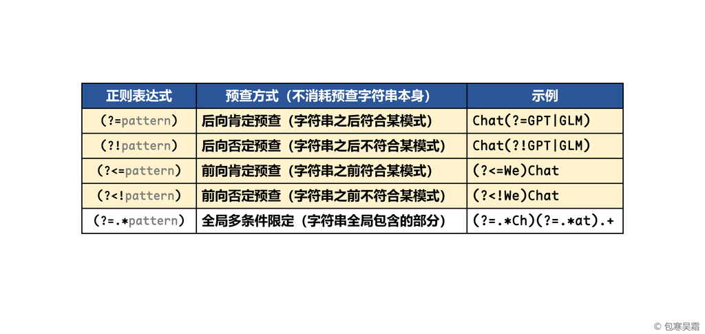

#### 【实践3】预查匹配

```r
text = "笔记本上安装SPSS22或20，授权码复制不上，导致安装失败。已经试了多次了，都安装不上SpSS，请问有遇到这种情况的吗？电脑是64位的，Spss是32位的，是这个原因吗？之前SpsS在其他笔记本和台式电脑上都安装成功了。"
cat(text)
```

```
笔记本上安装SPSS22或20，授权码复制不上，导致安装失败。已经试了多次了，都安装不上SpSS，请问有遇到这种情况的吗？电脑是64位的，Spss是32位的，是这个原因吗？之前SpsS在其他笔记本和台式电脑上都安装成功了。
```

```r
str_extract_all(text, "\\d{2}位")
```

```
[[1]]
[1] "64位" "32位"
```

```r
str_extract_all(text, "\\d{2}(?=位)")  # 后向肯定预查
```

```
[[1]]
[1] "64" "32"
```

```r
str_extract_all(text, "\\d{2}(?!位)")  # 后向否定预查
```

```
[[1]]
[1] "22" "20"
```

```r
str_extract_all(text, "(?<=SPSS)\\d{2}")  # 前向肯定预查
```

```
[[1]]
[1] "22"
```

```r
str_extract_all(text, "(?<!SPSS)\\d{2}")  # 前向否定预查
```

```
[[1]]
[1] "20" "64" "32"
```

# 字符串处理实战

`stringr`包

- 共同参数
  - `string`：字符串输入
  - `pattern`：正则表达式
- 常用函数
  - 判断：`str_detect()`
  - 计数：`str_count()`
  - 提取：`str_extract()`、`str_extract_all()`
  - 替换：`str_replace()`、`str_replace_all()`
  - 删除：`str_remove()`、`str_remove_all()`
  - 分割：`str_split()`
  - 向量取匹配子集：`str_subset()`

#### 【实践4】字符串综合处理

- 课程回顾：[Chap03 # 静态网页解析](https://psychbruce.github.io/RCourse/Chap03#%E5%AE%9E%E8%B7%B55%E9%9D%99%E6%80%81%E7%BD%91%E9%A1%B5%E8%A7%A3%E6%9E%90)
- 网页素材：[华东师范大学心理与认知科学学院“师资队伍”](https://psy.ecnu.edu.cn/17437/list.htm)

```r
## 数据采集
## 已加载rvest包：library(rvest)
url = "https://psy.ecnu.edu.cn/17437/list.htm"  # 学院师资队伍页面
xml = url %>% read_html()  # 读取网页所有信息
xml
```

```
{html_document}
<html class="webplus-list">
[1] <head>\n<meta http-equiv="Content-Type" content="text/html; charset=UTF-8">\ ...
[2] <body class="wp-column-page">\r\n<!--头部开始-->\r\n<header class="wp-wrapper wp ...
[3] <script type="text/javascript" src="/_upload/tpl/0b/a5/2981/template2981/js/ ...
[4] <script type="text/javascript">\r\n$(function(){\r\n\t// 初始化SDAPP\r\n\tnew S ...
```

```r
## 字符串处理（1）：院系名称
menu = xml %>% html_elements(".column-item-link .column-name") %>% html_text2()
menu
```

```
 [1] "各级人才工程"               "认知与神经科学系"
 [3] "毕生发展与学习科学系"       "社会与管理心理学系"
 [5] "健康与临床心理学系"         "人工智能与人因工程系（筹）"
 [7] "实验员/专任助理研究员"      "党政管理"
 [9] "兼职教师"                   "全职博士后"
[11] "荣休教师"                   "永远怀念教师名录"
```

```r
str_subset(menu, "系")
```

```
[1] "认知与神经科学系"           "毕生发展与学习科学系"
[3] "社会与管理心理学系"         "健康与临床心理学系"
[5] "人工智能与人因工程系（筹）"
```

```r
str_subset(menu, "系$")
```

```
[1] "认知与神经科学系"     "毕生发展与学习科学系" "社会与管理心理学系"
[4] "健康与临床心理学系"
```

```r
str_subset(menu, ".*系$")
```

```
[1] "认知与神经科学系"     "毕生发展与学习科学系" "社会与管理心理学系"
[4] "健康与临床心理学系"
```

```r
str_subset(menu, ".*(?=系$)")  # 只是取子集，并不能预查提取
```

```
[1] "认知与神经科学系"     "毕生发展与学习科学系" "社会与管理心理学系"
[4] "健康与临床心理学系"
```

```r
str_extract(menu, ".*(?=系$)")  # 真正的预查提取
```

```
 [1] NA                   "认知与神经科学"     "毕生发展与学习科学"
 [4] "社会与管理心理学"   "健康与临床心理学"   NA
 [7] NA                   NA                   NA
[10] NA                   NA                   NA
```

```r
str_extract(menu, ".*(?=系$)") %>% na.omit()  # 移除缺失值NA
```

```
[1] "认知与神经科学"     "毕生发展与学习科学" "社会与管理心理学"
[4] "健康与临床心理学"
attr(,"na.action")
[1]  1  6  7  8  9 10 11 12
attr(,"class")
[1] "omit"
```

```r
## 字符串处理（2）：人才计划
title = xml %>% html_elements(".subcolumn-name") %>% html_text2()
title
```

```
 [1] "华东师范大学特聘教授"     "国家级人才项目"
 [3] "国家级青年人才项目"       "中国科协托举人才"
 [5] "教育部新世纪人才"         "上海市曙光学者"
 [7] "上海市浦江学者"           "上海市青年科技启明星项目"
 [9] "上海市晨光计划"           "上海市扬帆计划"
```

```r
str_subset(title, "人才")
```

```
[1] "国家级人才项目"     "国家级青年人才项目" "中国科协托举人才"
[4] "教育部新世纪人才"
```

```r
str_subset(title, "人才$")
```

```
[1] "中国科协托举人才" "教育部新世纪人才"
```

```r
str_subset(title, "上海市.*")
```

```
[1] "上海市曙光学者"           "上海市浦江学者"
[3] "上海市青年科技启明星项目" "上海市晨光计划"
[5] "上海市扬帆计划"
```

```r
str_subset(title, "^上海市")
```

```
[1] "上海市曙光学者"           "上海市浦江学者"
[3] "上海市青年科技启明星项目" "上海市晨光计划"
[5] "上海市扬帆计划"
```

```r
str_extract(title, "(?<=^上海市).*(?=学者$|计划$)") %>% na.omit()
```

```
[1] "曙光" "浦江" "晨光" "扬帆"
attr(,"na.action")
[1] 1 2 3 4 5 8
attr(,"class")
[1] "omit"
```

```r
## 字符串处理（3）：教师姓名
name = xml %>% html_elements(".column-news-title") %>% html_text2()
name
```

```
 [1] "周晓林 博士"   "蒯曙光 博士"   "周晓林 博士"   "蔡清 博士"
 [5] "郝宁 博士"     "蒯曙光 博士"   "高晓雪 博士"   "罗艺 博士"
 [9] "崔丽娟 博士"   "刘永芳 博士"   "庞维国 博士"   "郝宁 博士"
[13] "刘俊升 博士"   "陆静怡 博士"   "蔡清 博士"     "包寒吴霜 博士"
[17] "李先春 博士"   "刘俊升 博士"   "孟慧 博士"     "庞维国 博士"
[21] "宋永宁博士"    "王弘毅 博士"   "王青 博士"     "席居哲 博士"
[25] "谢鑫宇博士"    "周宁宁 博士"   "张琪 博士"     "包寒吴霜 博士"
[29] "梁一鸣 博士"   "陆静怡 博士"   "王青 博士"     "杨莹 博士"
[33] "周晗昱 博士"   "陈 曦 博士"    "梁一鸣 博士"   "李世佳 博士"
[37] "杨莹 博士"     "周晗昱 博士"
```

```r
table(name)
```

```
name
包寒吴霜 博士     蔡清 博士    陈 曦 博士   崔丽娟 博士   高晓雪 博士
            2             2             1             1             1
    郝宁 博士   蒯曙光 博士   李世佳 博士   李先春 博士   梁一鸣 博士
            2             2             1             1             2
  刘俊升 博士   刘永芳 博士   陆静怡 博士     罗艺 博士     孟慧 博士
            2             1             2             1             1
  庞维国 博士    宋永宁博士   王弘毅 博士     王青 博士   席居哲 博士
            2             1             1             2             1
   谢鑫宇博士     杨莹 博士     张琪 博士   周晗昱 博士   周宁宁 博士
            1             2             1             2             1
  周晓林 博士
            2
```

```r
unique(name)
```

```
 [1] "周晓林 博士"   "蒯曙光 博士"   "蔡清 博士"     "郝宁 博士"
 [5] "高晓雪 博士"   "罗艺 博士"     "崔丽娟 博士"   "刘永芳 博士"
 [9] "庞维国 博士"   "刘俊升 博士"   "陆静怡 博士"   "包寒吴霜 博士"
[13] "李先春 博士"   "孟慧 博士"     "宋永宁博士"    "王弘毅 博士"
[17] "王青 博士"     "席居哲 博士"   "谢鑫宇博士"    "周宁宁 博士"
[21] "张琪 博士"     "梁一鸣 博士"   "杨莹 博士"     "周晗昱 博士"
[25] "陈 曦 博士"    "李世佳 博士"
```

```r
name %>% unique() %>% sort()
```

```
 [1] "包寒吴霜 博士" "蔡清 博士"     "陈 曦 博士"    "崔丽娟 博士"
 [5] "高晓雪 博士"   "郝宁 博士"     "蒯曙光 博士"   "李世佳 博士"
 [9] "李先春 博士"   "梁一鸣 博士"   "刘俊升 博士"   "刘永芳 博士"
[13] "陆静怡 博士"   "罗艺 博士"     "孟慧 博士"     "庞维国 博士"
[17] "宋永宁博士"    "王弘毅 博士"   "王青 博士"     "席居哲 博士"
[21] "谢鑫宇博士"    "杨莹 博士"     "张琪 博士"     "周晗昱 博士"
[25] "周宁宁 博士"   "周晓林 博士"
```

```r
name %>% unique() %>% sort() %>% str_remove_all("博士|\\s")
```

```
 [1] "包寒吴霜" "蔡清"     "陈曦"     "崔丽娟"   "高晓雪"   "郝宁"     "蒯曙光"
 [8] "李世佳"   "李先春"   "梁一鸣"   "刘俊升"   "刘永芳"   "陆静怡"   "罗艺"
[15] "孟慧"     "庞维国"   "宋永宁"   "王弘毅"   "王青"     "席居哲"   "谢鑫宇"
[22] "杨莹"     "张琪"     "周晗昱"   "周宁宁"   "周晓林"
```

```r
name %>%
  unique() %>%
  sort() %>%
  str_remove_all("博士|\\s") %>%
  str_subset("宁")
```

```
[1] "郝宁"   "宋永宁" "周宁宁"
```

```r
name %>%
  unique() %>%
  sort() %>%
  str_remove_all("博士|\\s") %>%
  str_subset("^赵|^钱|^孙|^李")  # 赵钱孙李，周吴郑王
```

```
[1] "李世佳" "李先春"
```

```r
name %>%
  unique() %>%
  sort() %>%
  str_remove_all("博士|\\s") %>%
  str_subset("^[周吴郑王]")  # 赵钱孙李，周吴郑王
```

```
[1] "王弘毅" "王青"   "周晗昱" "周宁宁" "周晓林"
```

```r
## 补充：字符向量 vs. 固定位置字符提取
"Psychology"[1]  # 长度为1的字符向量，[1]仍然是字符串，而不是第1个字母
```

```
[1] "Psychology"
```

```r
str_sub("Psychology", 1, 1)  # 提取第1个字母
```

```
[1] "P"
```

```r
str_sub("Psychology", 1, 5)  # 提取第1~5个字母
```

```
[1] "Psych"
```

- [豆瓣电影示例数据(.RData)](https://psychbruce.github.io/RCourse/data/douban_movies.RData)

```r
## 导入在线数据（douban_movies.RData）
data = import("https://psychbruce.github.io/RCourse/data/douban_movies.RData")
dt = as.data.table(data)
```

**课堂实战练习（问题解决导向的学习）：**

- 从电影标题变量（`title`）提取电影的上映年份
- 选取带有0~9数字的电影标题
- 选取带有年份数字的电影标题
- 选取模式为“高考1977”的电影标题
- ……

#### 【探索发现】stringr包的函数功能

- 检测匹配

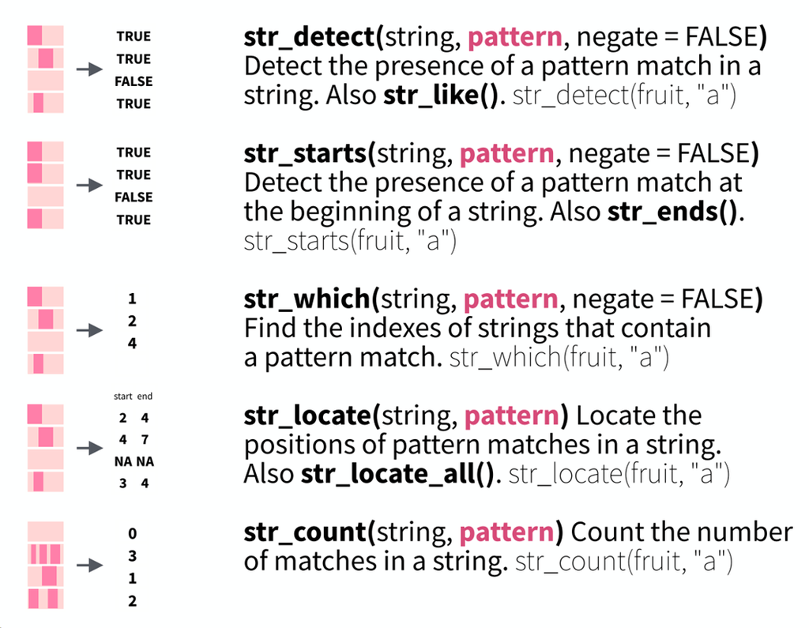

- 子集提取

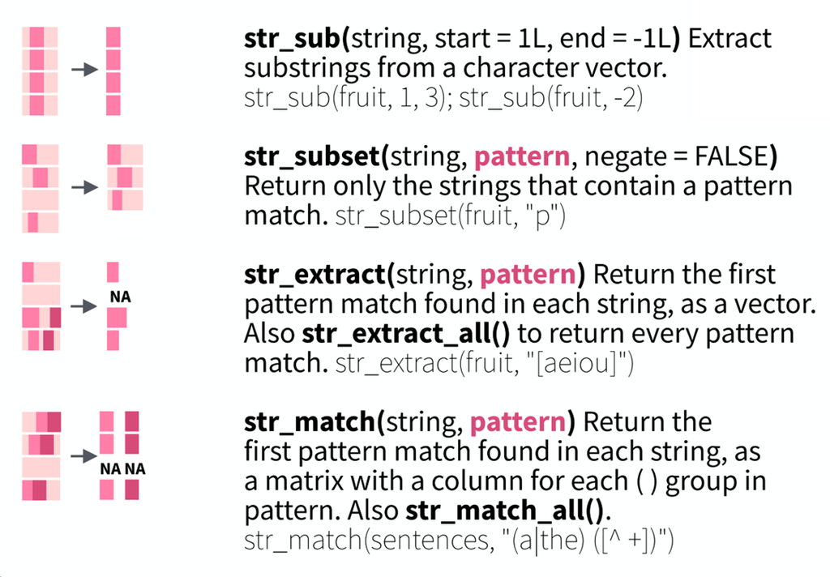

- 长度控制

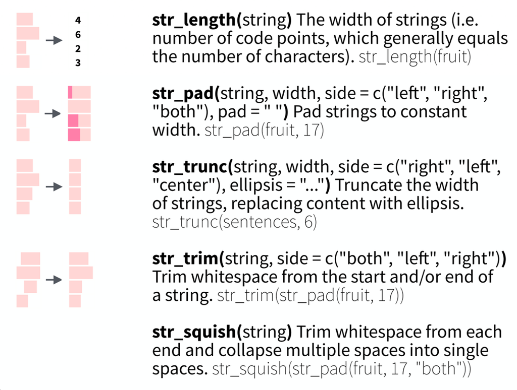

- 替换修改

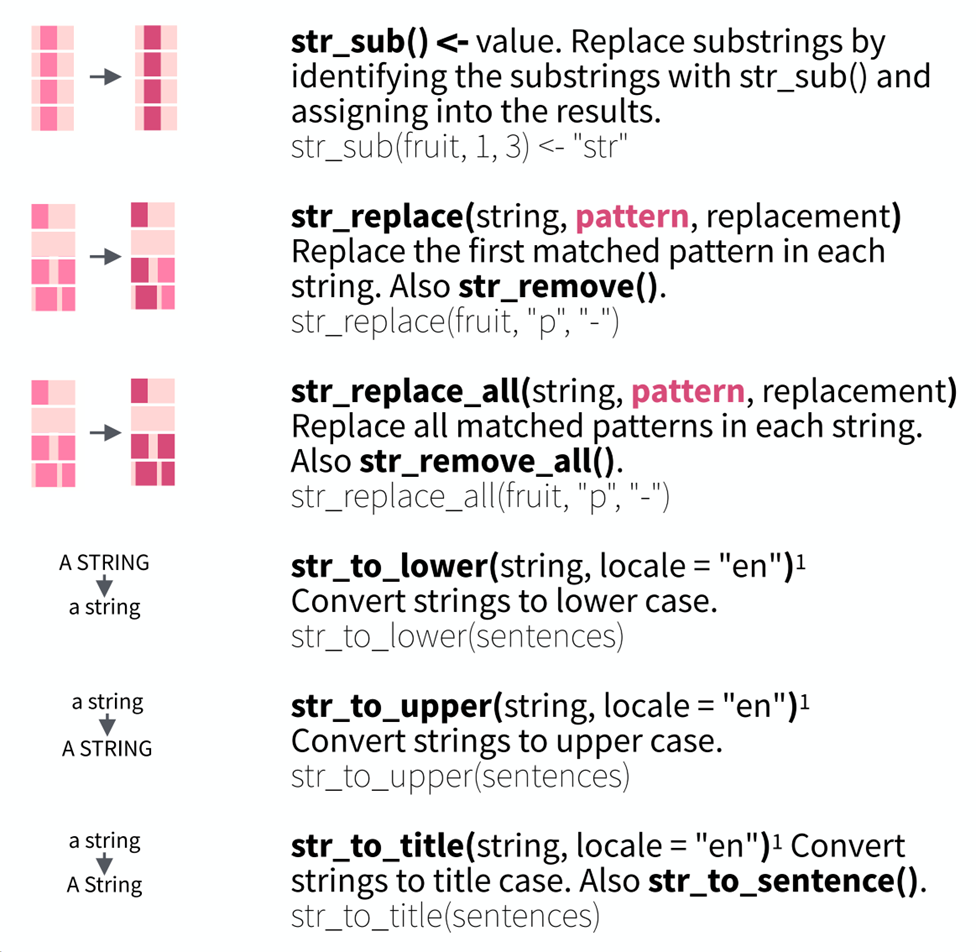

- 拼接分割

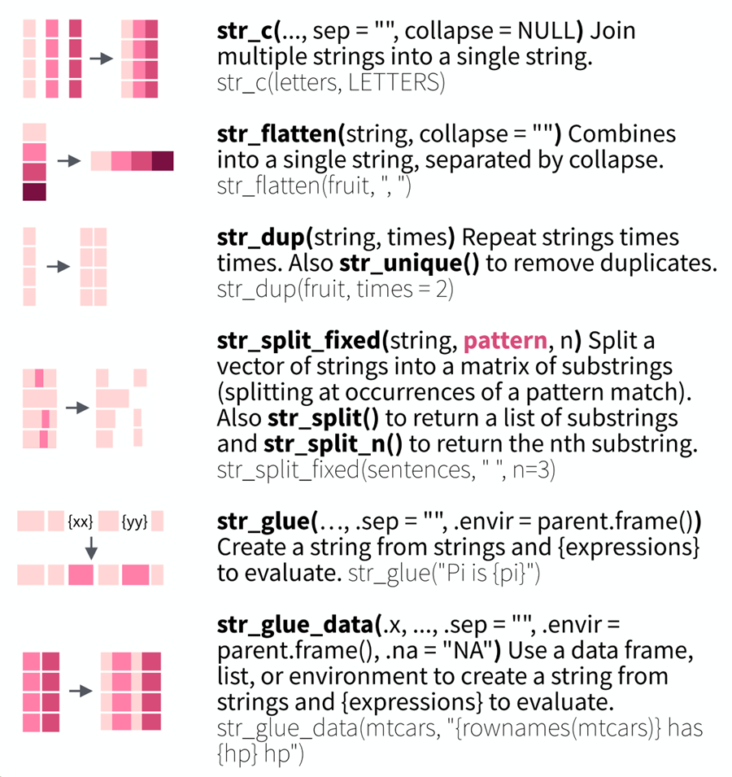

# 【作业5】字符向量处理

作业要求：

- 围绕`stringr`包提供的字符串示例数据`fruit`（80个水果名称），运用`str_detect()`、`str_subset()`、`str_extract_all()`、`str_replace_all()`等`stringr`包函数中的至少2个，任意完成至少2种字符串处理任务，并对代码和结果进行简单的注释和解读
- 使用R Markdown完成，运行渲染得到本地HTML网页文件

平台提交：

- 运行得到HTML网页文件的**关键部分截图（只需上传截图）**

```r
## 附：作业需要用到的数据集（字符向量）
stringr::fruit
```

```
 [1] "apple"             "apricot"           "avocado"
 [4] "banana"            "bell pepper"       "bilberry"
 [7] "blackberry"        "blackcurrant"      "blood orange"
[10] "blueberry"         "boysenberry"       "breadfruit"
[13] "canary melon"      "cantaloupe"        "cherimoya"
[16] "cherry"            "chili pepper"      "clementine"
[19] "cloudberry"        "coconut"           "cranberry"
[22] "cucumber"          "currant"           "damson"
[25] "date"              "dragonfruit"       "durian"
[28] "eggplant"          "elderberry"        "feijoa"
[31] "fig"               "goji berry"        "gooseberry"
[34] "grape"             "grapefruit"        "guava"
[37] "honeydew"          "huckleberry"       "jackfruit"
[40] "jambul"            "jujube"            "kiwi fruit"
[43] "kumquat"           "lemon"             "lime"
[46] "loquat"            "lychee"            "mandarine"
[49] "mango"             "mulberry"          "nectarine"
[52] "nut"               "olive"             "orange"
[55] "pamelo"            "papaya"            "passionfruit"
[58] "peach"             "pear"              "persimmon"
[61] "physalis"          "pineapple"         "plum"
[64] "pomegranate"       "pomelo"            "purple mangosteen"
[67] "quince"            "raisin"            "rambutan"
[70] "raspberry"         "redcurrant"        "rock melon"
[73] "salal berry"       "satsuma"           "star fruit"
[76] "strawberry"        "tamarillo"         "tangerine"
[79] "ugli fruit"        "watermelon"
```

[返回课程主页](https://psychbruce.github.io/RCourse/)

© 包寒吴霜